# Chapter 4

Rika Gorn

December 25, 2018

## Grouping in ggplot

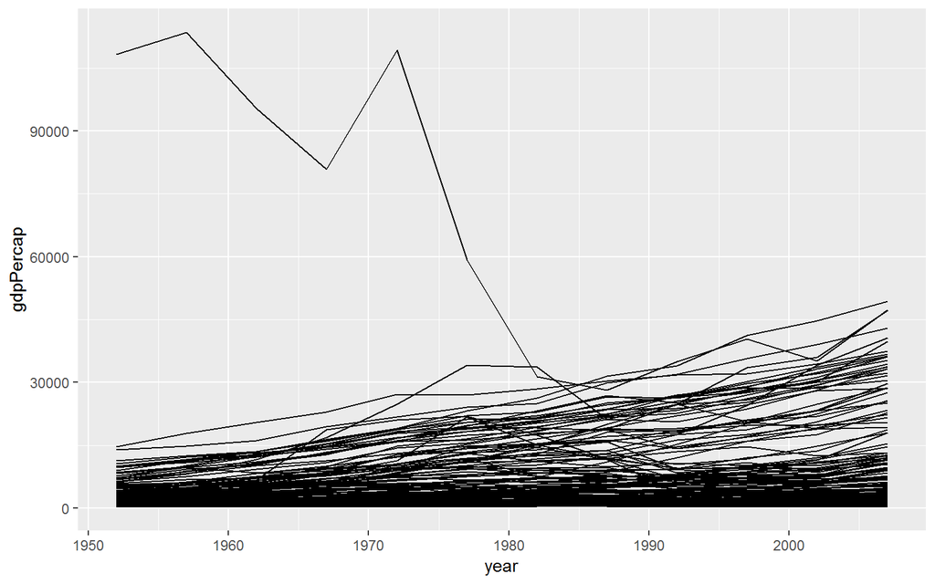

```r
p <- ggplot(data = gapminder, mapping = aes(x = year, y = gdpPercap))
p + geom_line(aes(group = country))
```

Each line represents a country with Kuwait being the outlier line, though the number of countries makes the chart nearly unreadable. Let’s separate the chart into multiples using `facet_wrap()`.

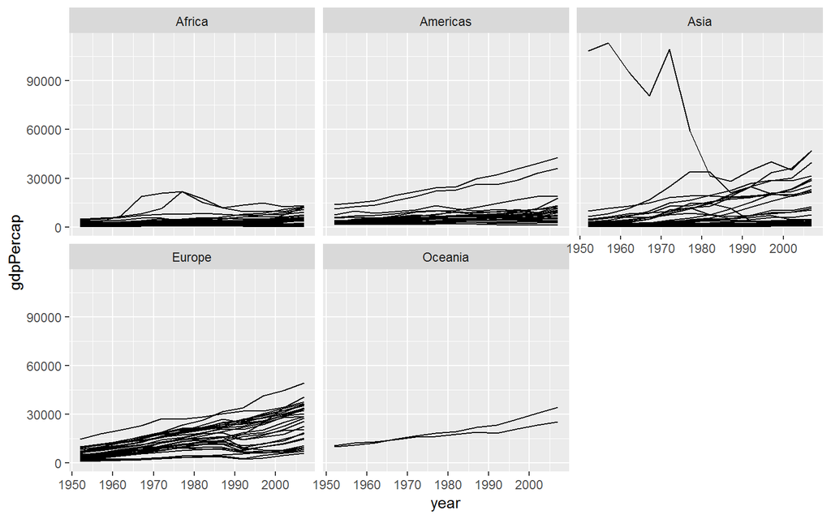

```r
p <- ggplot(data = gapminder, mapping = aes(x = year, y = gdpPercap))
p + geom_line(aes(group = country)) + facet_wrap(~continent)
```

This is looking a little better and now I’m very curious about the country in Asia where gdp went down over time.

```r
gapminder %>%
    select(continent, country, gdpPercap) %>%
    filter(continent == "Asia") %>%
    group_by(country) %>%
    summarise(mean = mean(gdpPercap)) %>%
    arrange(mean)
```

```
## # A tibble: 33 x 2
##    country      mean
##    <fct>       <dbl>
##  1 Myanmar      439.
##  2 Cambodia     675.
##  3 Nepal        783.
##  4 Afghanistan  803.
##  5 Bangladesh   818.
##  6 Vietnam     1018.
##  7 India       1057.
##  8 Pakistan    1439.
##  9 China       1488.
## 10 Yemen, Rep. 1569.
## # ... with 23 more rows
```

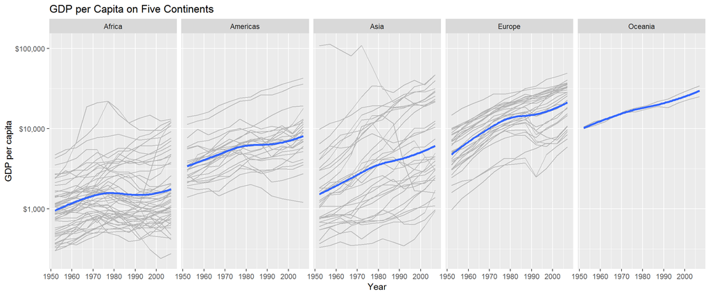

```r
p <- ggplot(data = gapminder, mapping = aes(x = year, y = gdpPercap))
p + geom_line(aes(group = country), color = "gray70") +
    geom_smooth(size = 1.1, method = "loess", se = FALSE) +
    scale_y_log10(labels = scales::dollar) +
    facet_wrap(~continent, ncol = 5) +
    labs(x = "Year",
         y = "GDP per capita",
         title = "GDP per Capita on Five Continents")
```

## New Data and Transforming Data

The next few charts use data from the 2016 General Social Survey or GSS which contains a variety of categorical variables that we can transform.

```r
glimpse(gss_sm)
```

```
## Observations: 2,867
## Variables: 32
## $ year        <dbl> 2016, 2016, 2016, 2016, 2016, 2016, 2016, 2016, 20...
## $ id          <dbl> 1, 2, 3, 4, 5, 6, 7, 8, 9, 10, 11, 12, 13, 14, 15,...
## $ ballot      <dbl> 1, 2, 3, 1, 3, 2, 1, 3, 1, 3, 2, 1, 2, 3, 2, 3, 3,...
## $ age         <dbl> 47, 61, 72, 43, 55, 53, 50, 23, 45, 71, 33, 86, 32...
## $ childs      <dbl> 3, 0, 2, 4, 2, 2, 2, 3, 3, 4, 5, 4, 3, 5, 7, 2, 6,...
## $ sibs        <dbl> 2, 3, 3, 3, 2, 2, 2, 6, 5, 1, 4, 4, 3, 6, 0, 1, 3,...
## $ degree      <fct> Bachelor, High School, Bachelor, High School, Grad...
## $ race        <fct> White, White, White, White, White, White, White, O...
## $ sex         <fct> Male, Male, Male, Female, Female, Female, Male, Fe...
## $ region      <fct> New England, New England, New England, New England...
## $ income16    <fct> $170000 or over, $50000 to 59999, $75000 to $89999...
## $ relig       <fct> None, None, Catholic, Catholic, None, None, None, ...
## $ marital     <fct> Married, Never Married, Married, Married, Married,...
```

[output cut: 19 more lines]

## Graph 1

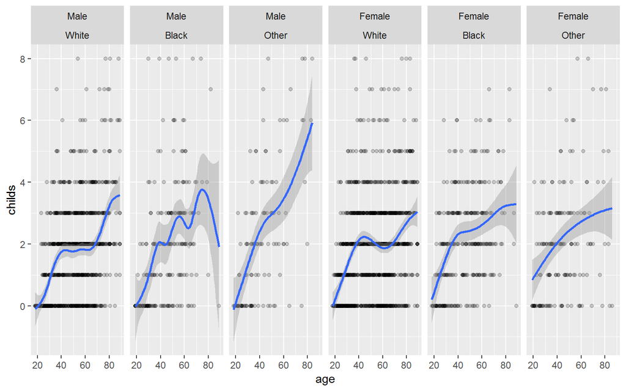

```r
p <- ggplot(data = gss_sm, mapping = aes(x = age, y = childs))
p + geom_point(alpha = 0.2) +
    geom_smooth() +
    facet_grid(~ sex + race)
```

-Uses `facet_grid` rather than `facet_wrap` to summarize across multiple categorical variables

-Adding an + in the grid function to the right side of the ~ includes additional variables with the column variable

## Graph 2

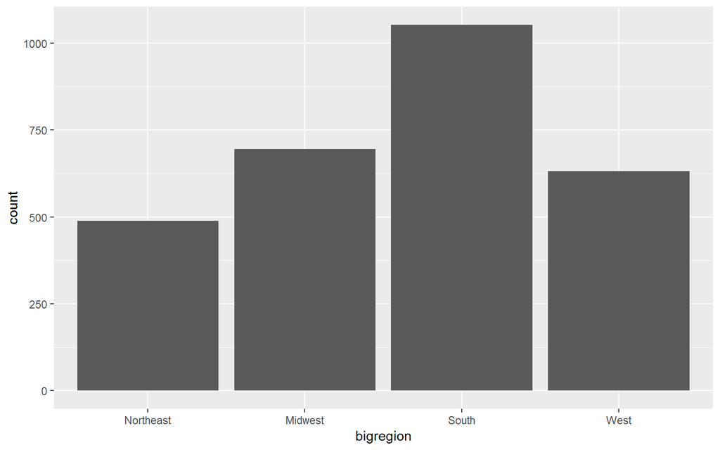

```r
p <- ggplot(data = gss_sm, mapping = aes(x = bigregion))
p + geom_bar()
```

-stat behind geom_bar is count

-not the biggest fan of that little space above the x-axis but hopefully can find something that fixes that

–expand_limits moves the chart to the right so that’s not good and scale_y_continuous moves the chart up, so will see

## Graph 3

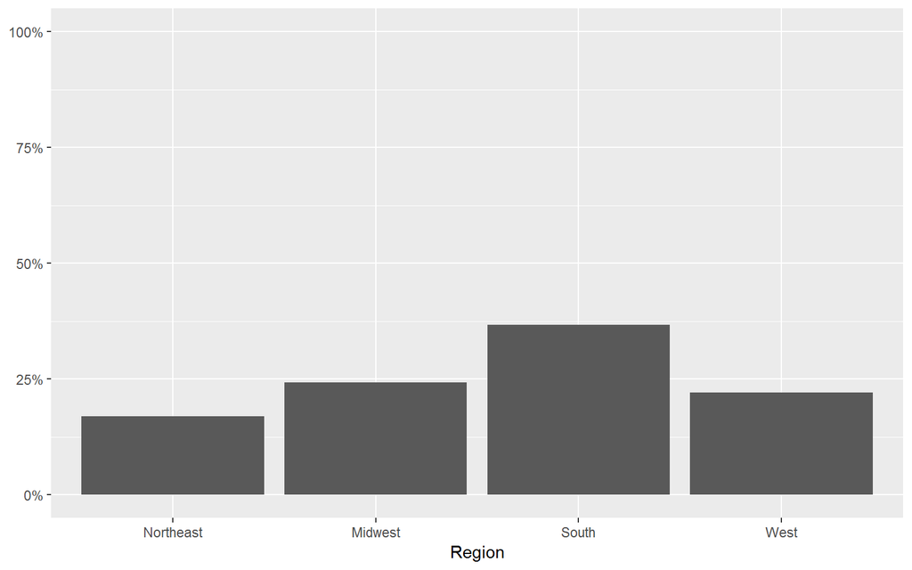

```r
p + geom_bar(mapping = aes(y = ..prop.., group = 1)) +
    scale_y_continuous(labels = percent_format(accuracy = 1), limits = c(0, 1)) +
    labs(x = "Region", y = NULL) +
    guides(fill = FALSE)
```

-Important to put group = 1 otherwise get all the bars with a height of 1.0 -Loving the `scales` package which easily changes the labels to percent and scales my axis to 100% -Not specifiying the fill as a factor gives you a continuous color scale which is not what we want here

## Graph 4